[Statology](https://www.statology.org/)

Statistics Made Easy

Posted on [May 27, 2019April 14, 2020](https://www.statology.org/how-to-read-the-f-distribution-table/) by [Zach](https://www.statology.org/author/admin/)

# How to Read the F-Distribution Table

This tutorial explains how to read and interpret [the F-distribution table](https://www.statology.org/f-distribution-table/).

### **What is the F-Distribution Table?**

The **F-distribution table** is a table that shows the critical values of the F distribution. To use the F distribution table, you only need three values:

- The numerator degrees of freedom
- The denominator degrees of freedom
- The alpha level (common choices are 0.01, 0.05, and 0.10)

The following table shows the F-distribution table for alpha = 0.10. The numbers along the top of the table represent the numerator degrees of freedom (labeled as *DF1* in the table) and the numbers along the left hand side of the table represent the denominator degrees of freedom (labeled as *DF2* in the table).

*Feel free to click on the table to zoom in.*

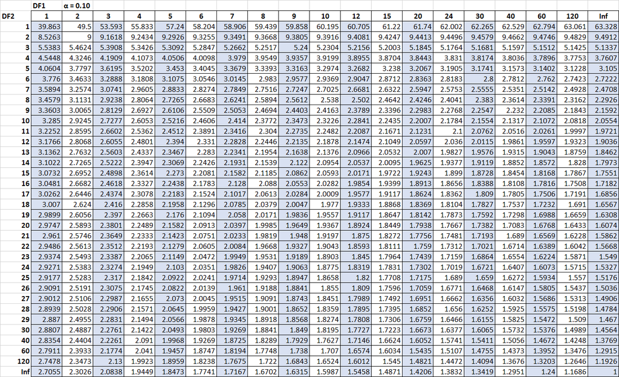

The critical values within the table are often compared to the F statistic of an F test. If the F statistic is greater than the critical value found in the table, then you can reject the null hypothesis of the F test and conclude that the results of the test are statistically significant.

## **Examples of How to Use the F-Distribution Table**

The F-distribution table is used to find the critical value for an F test. The three most common scenarios in which you’ll conduct an F test are as follows:

- F test in regression analysis to test for the overall significance of a regression model.
- F test in ANOVA (analysis of variance) to test for an overall difference between group means.
- F test to find out if two populations have equal variances.

Let’s walk through an example of how to use the F-distribution table in each of these scenarios.